# Weight Lifting Exercises Prediction Assignment

Remco Bekker

4-2-2019

## Introduction

This report is my elaboration of the Weight Lifting Exercises Prediction Assignment for the John Hopkins University Coursera Practical machine learning course.

Data was collected from accelerometers on the belt, forearm, arm, and dumbell of 6 participants while they were doing 10 repetitions of the Unilateral Dumbbell Biceps Curl in five different fashions: exactly according to the specification (Class A), throwing the elbows to the front (Class B), lifting the dumbbell only halfway (Class C), lowering the dumbbell only halfway (Class D) and throwing the hips to the front (Class E).

The goal of this project is to predict the manner in which they did the exercise. This is the “classe” variable in the training set. Any of the other variables may be used to predict with. This report describes:

- How the model was built
- How cross validation was used
- What the expected out of sample error is
- Which choices I made along the way
- Prediction of the 20 different test cases

The authors of te following paper http://web.archive.org/web/20161224072740/http:/groupware.les.inf.puc-rio.br/work.jsf?p1=11201 have been so kind to make the dataset available.

```r
## We need the following libraries...
library(caret)
library(randomForest)
## For reproducibility sake we set the seed
set.seed(5000)
## We read in the data that can be used for training and testing
data <- read.csv("pml-training.csv", stringsAsFactors = FALSE, na.strings = c("", "NA", "#DIV/0!"))
## The variable to be predicted is the "classe" variable and we turn that variable into a factor
data$classe <- as.factor(data$classe)
## The data in the testing dataset contains 20 observations that can be used for validating our prediction approach
validationData <- read.csv("pml-testing.csv", stringsAsFactors = FALSE, na.strings = c("", "NA", "#DIV/0!"))
```

## Exploratory analyses results and study design

In the appendix some exploratory analyses on the dataset have been performed. It turns out that the dataset contains two types of rows. Rows for which the “new_window” variable is “no” and those for which it is “yes”. The latter contain a number of variables that contain summary statistics (average, standard deviation etc.). However, the provided test set only contains rows with “new_window” == “no”. For this reason we will exclude the summary statistic variables.

Furthermore we slice the training dataset into a training and testset and use the provided test set as the validation set.

```r
## We don't use the first 7 columns as training or testing data as we are interested in prediction and not in understanding who or when an exercise was performed correctly.
subsetData <- data[, 8:ncol(data)]
## We also throw out the empty variables
subsetData <- subsetData[, setdiff(names(subsetData), retrieveEmptyVariables())]
## We want to create a dataset without the summary variables
subsetObservationalData <- subsetData[, setdiff(names(subsetData), retrieveSummaryVariables())]
## Next we create a training set and a test set so we can determine the out of sample error
inTrain <- createDataPartition(subsetObservationalData$classe, p = 0.8, list = FALSE)
trainingData <- subsetObservationalData[inTrain,]
testData <- subsetObservationalData[-inTrain,]
## The test set provided we will use as a validation set
subsetValidationData <- validationData[, 8:ncol(validationData)]
subsetValidationData <- subsetValidationData[, setdiff(names(subsetValidationData), retrieveEmptyVariables())]
subsetValidationData <- subsetValidationData[, setdiff(names(subsetValidationData), retrieveSummaryVariables())]
```

## Model selection

The to be predicted label is a factor with 5 levels. So we are dealing with a classification problem:

- Linear regression is not well suited for a classification problem
- Logistic regression is well suited for binary classification problems but we have 5 levels here
- KNN is not optimal when the number of observations relative to the number of variables is low, but since we train the model with approximately 50 variables and about 15000 observations, it is an option
- A classification tree based approach is also a good option
- Since prediction is the goal and not interpretability, a random forest or boosting approach could be used
- Random forest seems to produce a better accuracy than KNN so I will use the random forest model to predict the 20 cases in the validation set (I did include the KNN model and created a confusionmatrix for it for comparing the accuracy difference)
- A further extension could be to combine the 2 models but since the accuracy of the random forest model is so high I did not pursue this further

I used cross validation when building the random forest model (10 resampling iterations). Furthermore I have separated the training data into a separate training set and test set.

```r
## We train the model
rfModel <- train(classe ~ ., data = trainingData, ntree = 100, method = "rf", trControl = trainControl(method = "cv", number = 10, verboseIter = FALSE), prox = TRUE)
knnModel <- train(classe ~ ., data = trainingData, method = "knn", preProcess = c("center", "scale"))
## We can look at the models
print(rfModel)
```

```
## Random Forest
##
## 15699 samples
##    52 predictor
##     5 classes: 'A', 'B', 'C', 'D', 'E'
##
## No pre-processing
## Resampling: Cross-Validated (10 fold)
## Summary of sample sizes: 14129, 14129, 14129, 14129, 14129, 14130, ...
## Resampling results across tuning parameters:
##
##   mtry  Accuracy   Kappa
##    2    0.9926109  0.9906529
##   27    0.9934389  0.9917004
##   52    0.9856673  0.9818675
##
## Accuracy was used to select the optimal model using the largest value.
## The final value used for the model was mtry = 27.
```

```r
print(knnModel)
```

```
## k-Nearest Neighbors
##
## 15699 samples
##    52 predictor
##     5 classes: 'A', 'B', 'C', 'D', 'E'
##
## Pre-processing: centered (52), scaled (52)
## Resampling: Bootstrapped (25 reps)
## Summary of sample sizes: 15699, 15699, 15699, 15699, 15699, 15699, ...
## Resampling results across tuning parameters:
##
##   k  Accuracy   Kappa
##   5  0.9521829  0.9395101
##   7  0.9420929  0.9267373
##   9  0.9331322  0.9153888
##
## Accuracy was used to select the optimal model using the largest value.
## The final value used for the model was k = 5.
```

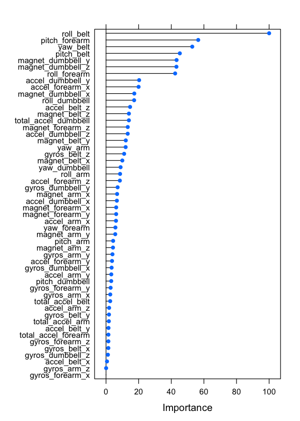

```r
## And visualize what what the most important variables are
plot(varImp(rfModel))
```

```r
## And we test the model on the test set
rfPredictions <- predict(object = rfModel, newdata = testData)
knnPredictions <- predict(object = knnModel, newdata = testData)
```

## Out of sample error

Now that we have trained the model on the training data, we can determine the out of sample error by applying the model to the test data set and creating a confusion matrix to see the accuracy related statistics. One can see that the random forest model performs better.

```r
confusionMatrix(rfPredictions, testData$classe)
```

```
## Confusion Matrix and Statistics
##
##           Reference
## Prediction    A    B    C    D    E
##          A 1115    7    0    0    0
##          B    1  751    3    0    0
##          C    0    1  679    5    0
##          D    0    0    2  637    0
##          E    0    0    0    1  721
##
## Overall Statistics
##
##                Accuracy : 0.9949
##                  95% CI : (0.9921, 0.9969)
##     No Information Rate : 0.2845
##     P-Value [Acc > NIR] : < 2.2e-16
##
##                   Kappa : 0.9936
##  Mcnemar's Test P-Value : NA
##
## Statistics by Class:
##
##                      Class: A Class: B Class: C Class: D Class: E
## Sensitivity            0.9991   0.9895   0.9927   0.9907   1.0000
## Specificity            0.9975   0.9987   0.9981   0.9994   0.9997
## Pos Pred Value         0.9938   0.9947   0.9912   0.9969   0.9986
## Neg Pred Value         0.9996   0.9975   0.9985   0.9982   1.0000
## Prevalence             0.2845   0.1935   0.1744   0.1639   0.1838
## Detection Rate         0.2842   0.1914   0.1731   0.1624   0.1838
## Detection Prevalence   0.2860   0.1925   0.1746   0.1629   0.1840
## Balanced Accuracy      0.9983   0.9941   0.9954   0.9950   0.9998
```

```r
confusionMatrix(knnPredictions, testData$classe)
```

```
## Confusion Matrix and Statistics
##
##           Reference
## Prediction    A    B    C    D    E
##          A 1104   20    0    3    0
##          B    2  722    6    0    6
##          C    6   14  664   22    5
##          D    3    1   13  615    1
##          E    1    2    1    3  709
##
## Overall Statistics
##
##                Accuracy : 0.9722
##                  95% CI : (0.9666, 0.9771)
##     No Information Rate : 0.2845
##     P-Value [Acc > NIR] : < 2.2e-16
##
##                   Kappa : 0.9648
##  Mcnemar's Test P-Value : 0.0001914
##
## Statistics by Class:
##
##                      Class: A Class: B Class: C Class: D Class: E
## Sensitivity            0.9892   0.9513   0.9708   0.9565   0.9834
## Specificity            0.9918   0.9956   0.9855   0.9945   0.9978
## Pos Pred Value         0.9796   0.9810   0.9339   0.9716   0.9902
## Neg Pred Value         0.9957   0.9884   0.9938   0.9915   0.9963
## Prevalence             0.2845   0.1935   0.1744   0.1639   0.1838
## Detection Rate         0.2814   0.1840   0.1693   0.1568   0.1807
## Detection Prevalence   0.2873   0.1876   0.1812   0.1614   0.1825
## Balanced Accuracy      0.9905   0.9734   0.9781   0.9755   0.9906
```

## Visualizing 2 most important variables

In the plot below it is shown that the two most important variables as determined by the random frorest algorithm do indeed have a very high explanatory power in terms of the classe label.

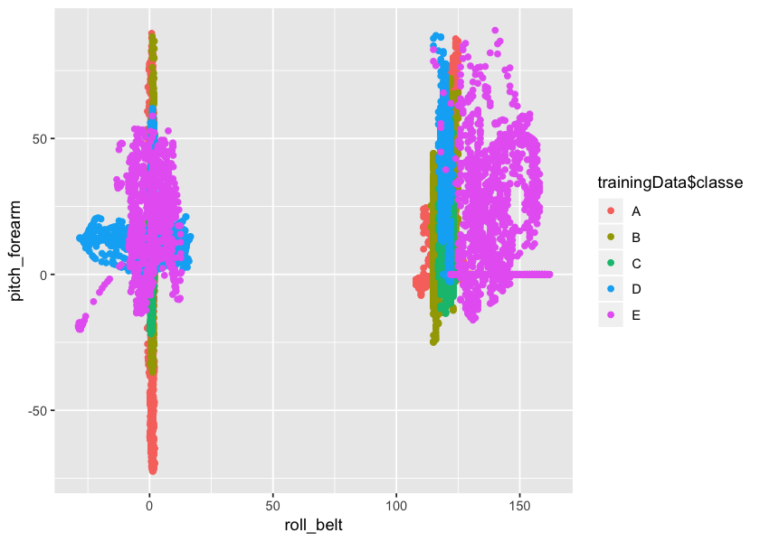

```r
## We can plot the 2 most important variables
importantVariables <- varImp(rfModel)$importance
importantVariables$var <- rownames(varImp(rfModel)$importance)
importantVariables <- importantVariables[order(importantVariables$Overall, decreasing = TRUE),]
xvar <- rownames(importantVariables)[1]
yvar <- rownames(importantVariables)[2]
qplot(x = trainingData[, xvar], y = trainingData[, yvar], xlab = xvar, ylab = yvar, colour = trainingData$classe)
```

## Validation set predictions

The final step is to put the training model to work on predicting the labels for the validation set.

```r
## Now that we have the final model, we can apply it to the validation set...
validationPredictions <- predict(rfModel, cbind(subsetValidationData, validationData$num_window))
## We print out the predicted labels
print(validationPredictions)
```

```
##  [1] B A B A A E D B A A B C B A E E A B B B
## Levels: A B C D E
```

```r
## If we join the validation data set with the original data set we can
## obtain the actual labels of the validation data set and create a confusion matrix.
validationDataOrder <- cbind(subsetValidationData, num_window = validationData$num_window)
validationActualLabels <- unique(merge(x = validationData, y = data, by = "num_window", all.x = TRUE)[, c("num_window", "classe")])
confusionMatrix(validationPredictions, validationActualLabels[match(validationDataOrder$num_window, validationActualLabels$num_window), "classe"])
```

```
## Confusion Matrix and Statistics
##
##           Reference
## Prediction A B C D E
##          A 7 0 0 0 0
##          B 0 8 0 0 0
##          C 0 0 1 0 0
##          D 0 0 0 1 0
##          E 0 0 0 0 3
##
## Overall Statistics
##
##                Accuracy : 1
##                  95% CI : (0.8316, 1)
##     No Information Rate : 0.4
##     P-Value [Acc > NIR] : 1.1e-08
##
##                   Kappa : 1
##  Mcnemar's Test P-Value : NA
##
## Statistics by Class:
##
##                      Class: A Class: B Class: C Class: D Class: E
## Sensitivity              1.00      1.0     1.00     1.00     1.00
## Specificity              1.00      1.0     1.00     1.00     1.00
## Pos Pred Value           1.00      1.0     1.00     1.00     1.00
## Neg Pred Value           1.00      1.0     1.00     1.00     1.00
## Prevalence               0.35      0.4     0.05     0.05     0.15
## Detection Rate           0.35      0.4     0.05     0.05     0.15
## Detection Prevalence     0.35      0.4     0.05     0.05     0.15
## Balanced Accuracy        1.00      1.0     1.00     1.00     1.00
```